# Lab 6.2 - Visualizing amounts, proportions and distributions

### Violin plots

Boxplots were invented by the statistician John Tukey in the early 1970s, and they quickly gained popularity because they were highly informative while being easy to draw by hand. Most data visualizations were drawn by hand at that time. However, with modern computing and visualization capabilities, we are not limited to what is easily drawn by hand. Therefore, more recently, we see boxplots being replaced by violin plots, which are equivalent to the density estimates discussed earlier but rotated by 90 degrees and then mirrored:

Violins can be used whenever one would otherwise use a boxplot, and they provide a much more nuanced picture of the data. In particular, violin plots will accurately represent bimodal data whereas a boxplot will not.

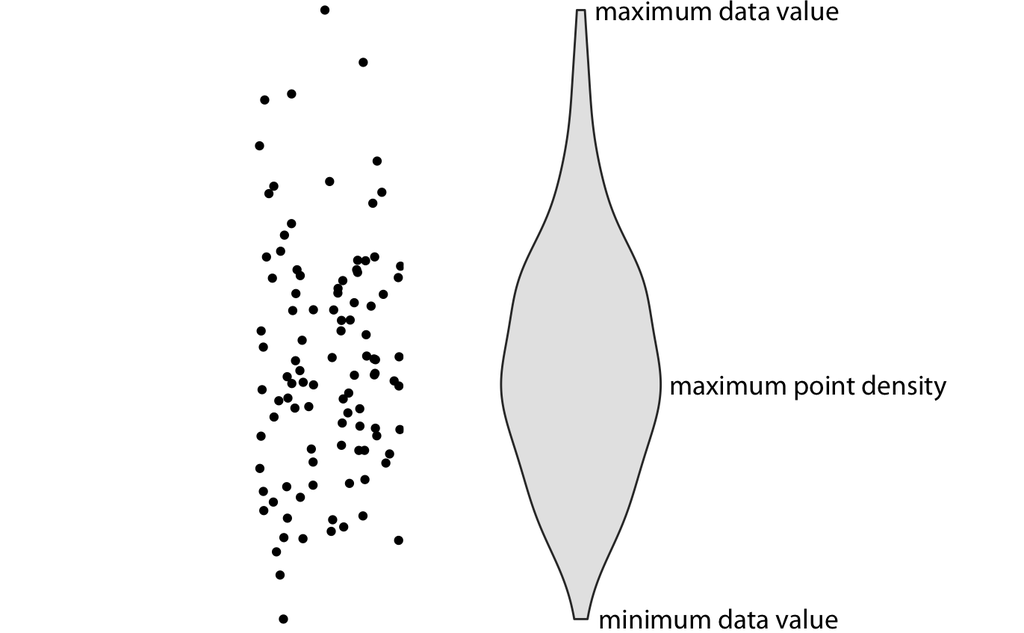

Anatomy of a violin plot. Shown are a cloud of points (left) and the corresponding violin plot (right). Only the y values of the points are visualized in the violin plot. The width of the violin at a given y value represents the point density at that y value. Technically, a violin plot is a density estimate rotated by 90 degrees and then mirrored. Violins are therefore symmetric. Violins begin and end at the minimum and maximum data values, respectively. The thickest part of the violin corresponds to the highest point density in the dataset. Source: Wilke (2019)

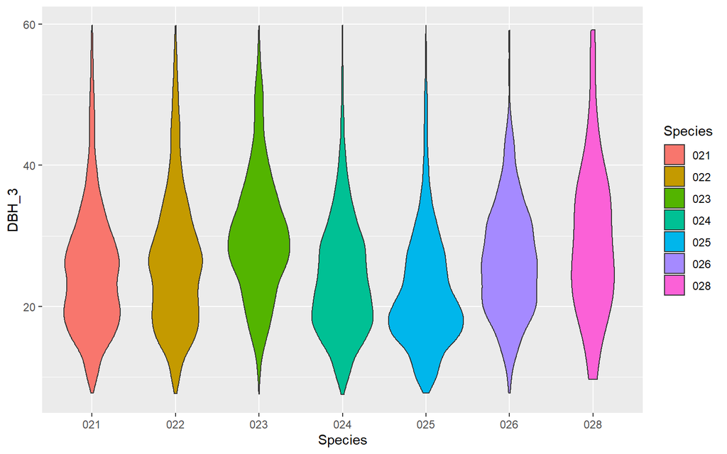

```r
pines %>%
    filter(DBH_3 < 60) %>%
    ggplot() +
    geom_violin(aes(x=Species, y = DBH_3, fill = Species))
```

We can even combine violin and box plots into the same figure, just adding two different layers of `geom`, first the violin and then the boxplot:

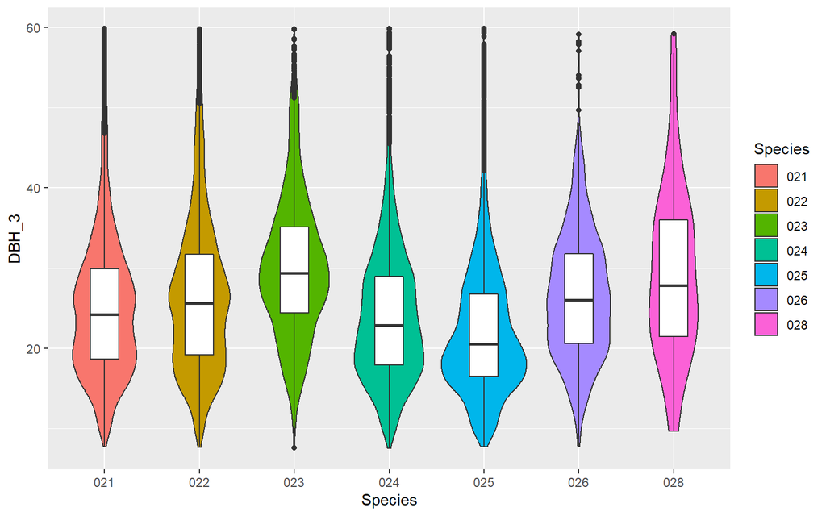

```r
pines %>%
    filter(DBH_3 < 60) %>%
    ggplot() +
    geom_violin(aes(x=Species, y = DBH_3, fill = Species)) +
    geom_boxplot(aes(x=Species, y = DBH_3), width = 0.3)
```

### Ridgeline plots

Ridgeline plots are an alternative to multiple group density plots. Their names comes because these plots look like mountain ridgelines.They are not always a good choice but when they fit the purpose, they are a quite stylish way to represent data. The standard ridgeline plot uses density estimates It is quite closely related to the violin plot, but frequently evokes a more intuitive understanding of the data. We must specify an `x` aesthetic, which will be the one to build the density upon, and a `y` aesthetic, that will control the groups to display.

`ggplot` does not include any `geom` to produce ridgeline plots, but we can access to the `geom_density_ridges()` function by loading the `ggridges` package.

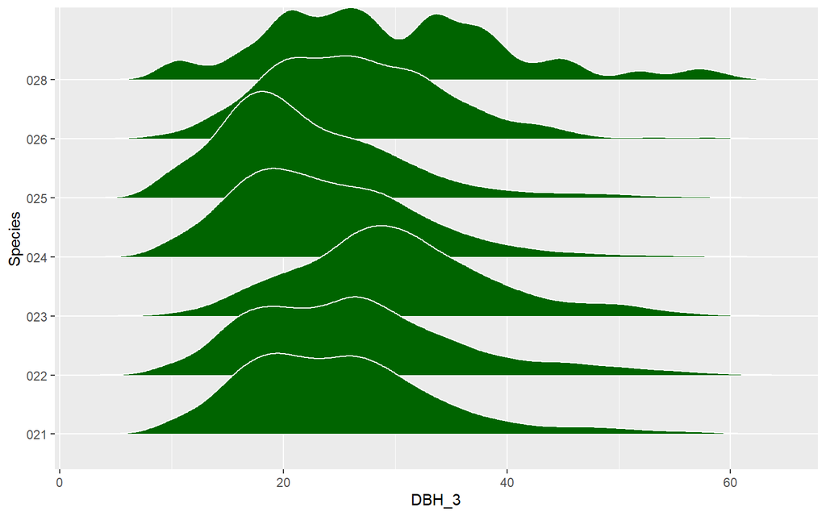

```r
library(ggridges)

pines %>%
    filter(DBH_3 < 60) %>%
    ggplot() +
    geom_density_ridges(aes(x=DBH_3,y=Species), color = "white", fill = "dark green")
```

Of course, we can also make the fill of the ridgelines vary with a variable:

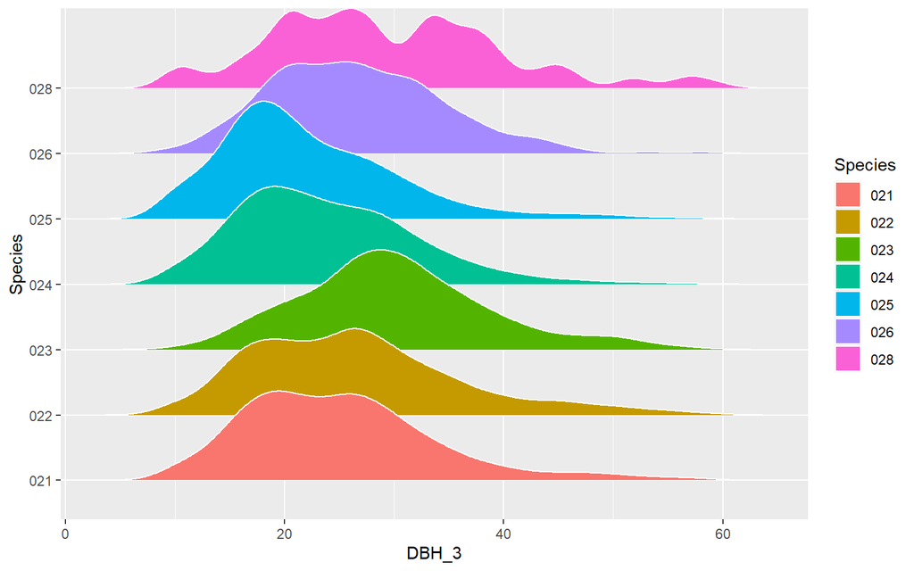

```r
pines %>%
    filter(DBH_3 < 60) %>%
    ggplot() +
    geom_density_ridges(aes(x = DBH_3, y = Species, fill = Species), color = "white")
```

**EXERCISE 3**

Make two plots representing the surface distribution of fires by cause, and discuss the advantages and limitations of each of them.

# References

Wilke, C. O. 2019. *Fundamentals of Data Visualization: A Primer on Making Informative and Compelling Figures*. O’Reilly Media, Incorporated. https://books.google.es/books?id=L3ajtgEACAAJ.